# Introduction to R

## The methods() function

```r
# what functions accept data frames as arguments?
methods(class="data.frame")
```

```
#>   [1] $              $<-            [              [[
#>   [5] [[<-           [<-            aggregate      anti_join
#>   [9] anyDuplicated  arrange        arrange_       as.data.frame
#>  [13] as.list        as.matrix      as.tbl         as.tbl_cube
#>  [17] as_data_frame  as_tibble      by             cbind
#>  [21] coerce         collapse       collect        complete
#>  [25] complete_      compute        dim            dimnames
#>  [29] dimnames<-     distinct       distinct_      do
#>  [33] do_            drop_na        drop_na_       droplevels
#>  [37] duplicated     edit           expand         expand_
#>  [41] extract        extract_       fill           fill_
#>  [45] filter         filter_        format         formula
#>  [49] fortify        full_join      gather         gather_
#>  [53] ggplot         glimpse        group_by       group_by_
#>  [57] group_indices  group_indices_ group_size     groups
```

[output cut: 19 more lines]

## Review: Data Structures

## Have you been paying attention?

Now we test what you've learned.

What will the object `a` contain here?

```r
a <- c(0, 1)
a
```

```r
a <- c(0, 1)
a
```

```
#> [1] 0 1
```

Now what will the object a contain?

```r
a <- c(10, seq(5, 1, -1))
a
```

```r
a <- c(10, seq(5, 1, -1))
a
```

```
#> [1] 10  5  4  3  2  1
```

What about now? What will a contain?

```r
a <- c(rep(0,2), seq(1,5,by=2))
a
```

```r
a <- c(rep(0,2), seq(1,5,by=2))
a
```

```
#> [1] 0 0 1 3 5
```

What will be the result of dim(b)?

```r
b <- data.frame(letters=c("a", "b", "c"), numbers=c(1,2,3))
dim(b)
```

```r
b <- data.frame(letters=c("a", "b", "c"), numbers=c(1,2,3))
dim(b)
```

```
#> [1] 3 2
```

What is the result of b[2,]?

```r
# What is the result of b[2,]?

b <- data.frame(letters=c("a", "b", "c"), numbers=c(1,2,3))
b[2,]
```

```r
# What is the result of b[2,]?

b <- data.frame(letters=c("a", "b", "c"), numbers=c(1,2,3))
b[2,]
```

```
#>   letters numbers
#> 2       b       2
```

What about the result of b[b$numbers<2,]?

```r
b <- data.frame(letters=c("a", "b", "c"), numbers=c(1,2,3))
b[b$numbers<2,]
```

```r
b <- data.frame(letters=c("a", "b", "c"), numbers=c(1,2,3))
b[b$numbers<2,]
```

```
#>   letters numbers
#> 1       a       1
```

What are three different ways to access "c" in data frame b?

```r
b <- data.frame(letters=c("a", "b", "c"), numbers=c(1,2,3))
```

Also, why does it keep saying "levels" in the output?

```r
b <- data.frame(letters=c("a", "b", "c"), numbers=c(1,2,3))

# letters column, element 3 (recommended method)
b$letters[3]
```

```
#> [1] c
#> Levels: a b c
```

```r
# row 3 column 1
b[3,1]
```

```
#> [1] c
#> Levels: a b c
```

```r
## [1] c


# element 1 (column 1) of data frame, then element 3 of that
b[[1]][3]
```

```
#> [1] c
#> Levels: a b c
```

```r
## [1] c
```

Because by default, character vectors are converted to factors in data.frame().

We know that `b` is a data.frame. Why do you think `mean(b)` does not work? What is `R` trying to tell us with the warning?

```r
# confirm that it is a data frame
class(b)
```

```
#> [1] "data.frame"
```

```r
# NA is not what we want, what is the warning trying to tell us?
mean(b)
```

```
#> [1] NA
```

`mean()` expects a numeric or logical vector as input, not a data frame. It doesn't know how to calculate the mean for several columns.

Subsetting a column of b results in a vector, which works as an input to `mean()`.

`methods(mean)` shows us that there is no mean function defined specifically for data frames.

```r
# columns of data frames are vectors
class(b$numbers)
```

```
#> [1] "numeric"
```

```r
mean(b$numbers)
```

```
#> [1] 2
```

```r
# no mean.data.frame
methods(mean)
```

```
#> [1] mean.Date     mean.default  mean.difftime mean.POSIXct  mean.POSIXlt
#> see '?methods' for accessing help and source code
```

## Importing Data

## Dataset files

R works most easily with datasets stored as text files. Typically, values in text files are separated, or delimited, by tabs or spaces:

[output not shown]

or by commas (CSV file):

```
gender,id,race,ses,schtyp,prgtype,read,write,math,science,socst
0,70,4,1,1,general,57,52,41,47,57
1,121,4,2,1,vocati,68,59,53,63,61
0,86,4,3,1,general,44,33,54,58,31
0,141,4,3,1,vocati,63,44,47,53,56
```

## Reading in text data

We recommend the tidyverse (specific package readr) functions read_csv() to read in data stored as CSV and `read_delim()` to read in text data delimited by other characters.

For `read_delim()`, specify the delimiter in the delim= argument.

(Base R functions `read.csv()` and `read.delim()` have very similar functionality, but have less useful default settings)

Although we are retrieving files over the internet for this class, these functions are typically used for files saved to disk.

Note how we are assigning the loaded data to objects.

```r
# run this if you missed it earlier
library(tidyverse)
```

In the output for read_csv() and read_delim(), you'll see the data type of each column.

```r
# comma separated values
dat_csv <- read_csv("https://stats.idre.ucla.edu/stat/data/hsbdemo.csv")
```

```r
# tab separated values
dat_tab <- read_delim("https://stats.idre.ucla.edu/stat/data/hsb2.txt",
                      delim="\t")
```

## Tibbles

If you attempt to print a data frame read in by read_csv() or read_delim(), it prints in special way:

```r
dat_csv
```

```
#> # A tibble: 200 x 13
#>       id female    ses schtyp     prog  read write  math science socst
#>    <int>  <chr>  <chr>  <chr>    <chr> <int> <int> <int>   <int> <int>
#>  1    45 female    low public vocation    34    35    41      29    26
#>  2   108   male middle public  general    34    33    41      36    36
#>  3    15   male   high public vocation    39    39    44      26    42
#>  4    67   male    low public vocation    37    37    42      33    32
#>  5   153   male middle public vocation    39    31    40      39    51
#>  6    51 female   high public  general    42    36    42      31    39
#>  7   164   male middle public vocation    31    36    46      39    46
#>  8   133   male middle public vocation    50    31    40      34    31
#>  9     2 female middle public vocation    39    41    33      42    41
#> 10    53   male middle public vocation    34    37    46      39    31
#> # ... with 190 more rows, and 3 more variables: honors <chr>,
#> #   awards <int>, cid <int>
```

This is because read_csv() assigns the data frame to a class called tibble, a tidyverse structure that slightly alters how data.frames behave, such as when they are being created or printed. Tibbles are still data frames, and will work in most functions that require data frame inputs.

Read more about tibbles [here](https://cran.r-project.org/web/packages/tibble/vignettes/tibble.html).

We can create tibbles manually in a nearly identical manner to data frames with `tibble()`.

To convert a tibble to a regular data frame, use `as.data.frame()`.

```r
# dat_csv is of class tibble (tbl_df), class table (tbl) and class data.frame

class(dat_csv)
```

```
#> [1] "tbl_df"     "tbl"        "data.frame"
```

```r
# now just a data.frame
class(as.data.frame(dat_csv))
```

```
#> [1] "data.frame"
```

## Reading in data from other statistical software

We can read in datasets from other statistical analysis software using functions found in the haven package, part of the tidyverse. Note, the haven package is not loaded with library(tidyverse) so must be loaded separately.

```r
require(haven)
## Loading required package: haven
# SPSS files
dat_spss <- read_spss("https://stats.idre.ucla.edu/stat/data/hsb2.sav")
# Stata files
dat_dta <- read_stata("https://stats.idre.ucla.edu/stat/data/hsbdemo.dta")
```

## Reading in Excel files

Datasets are often saved as Excel spreadsheets. Here we utilize the readxl package to read in the excel file. We need to download the file first.

```r
library(readxl)
# this step only needed to read excel files from the internet
download.file("https://stats.idre.ucla.edu/stat/data/hsb2.xls", "myfile.xls", mode="wb")

dat_xls <- read_excel("myfile.xls")
```

## Viewing data with `head()` and `tail()`

Use `head()` and `tail()` to look at a specified number of rows at the begininning or end of a dataset, respectively.

```r
# first 2 rows
head(dat_xls, 2)
```

```
#> # A tibble: 2 x 11
#>      id female  race   ses schtyp  prog  read write  math science socst
#>   <dbl>  <dbl> <dbl> <dbl>  <dbl> <dbl> <dbl> <dbl> <dbl>   <dbl> <dbl>
#> 1    70      0     4     1      1     1    57    52    41      47    57
#> 2   121      1     4     2      1     3    68    59    53      63    61
```

```r
# last 8 rows
tail(dat_csv, 8)
```

```
#> # A tibble: 8 x 13
#>      id female    ses  schtyp     prog  read write  math science socst
#>   <int>  <chr>  <chr>   <chr>    <chr> <int> <int> <int>   <int> <int>
#> 1   174   male middle private academic    68    59    71      66    56
#> 2    95   male   high  public academic    73    60    71      61    71
#> 3    61 female   high  public academic    76    63    60      67    66
#> 4   100 female   high  public academic    63    65    71      69    71
#> 5   143   male middle  public vocation    63    63    75      72    66
#> 6    68   male middle  public academic    73    67    71      63    66
#> 7    57 female middle  public academic    71    65    72      66    56
#> 8   132   male middle  public academic    73    62    73      69    66
#> # ... with 3 more variables: honors <chr>, awards <int>, cid <int>
```

## Viewing data as a spreadsheet with `View()`

Use `View()` on a dataset to open a spreadsheet-style view of a dataset. In RStuido, clicking on a dataset in the Environment pane will `View()` it.

```r
View(dat_csv)
```

## Exporting data

We can export our data in a number of formats, including text, Excel .xlsx, and in other statistical software formats like Stata .dta, using `write_` functions that reverse the operations of the `read_` functions.

Multiple objects can be stored in an R binary file (usally extension `.Rdata`) with `save()` and then later loaded with `load()`.

We did not specify realistic pathnames below.

```r
# write a csv file
write_csv(dat_csv, path =  "dat_csv.csv")

# Stata .dta file (need to load foreign package)
write_dta(dat_csv, path =  "dat_csv.dta")

# save these objects to an .Rdata file
save(dat_csv, file= "C:/Users/Dell/Dropbox/tridata/in-house-R-courses/dat_csv.Rdata")
```

## Review: Importing Data

In the file "http://stats.idre.ucla.edu/stat/data/hsbsemi.txt", the fields are separated by ";". What function could I use to read it in?

Here are how the first few rows appear:

```
id;female;ses;schtyp;prog;read;write;math;science;socst;honors;awards;cid
45;female;low;public;vocation;34;35;41;29;26;not enrolled;0;1
108;male;middle;public;general;34;33;41;36;36;not enrolled;0;1
```

Use read_delim() with delim=";"

```r
d_semi <- read_delim("https://stats.idre.ucla.edu/stat/data/hsbsemi.txt",
                     delim=";")
```

## Data Exploration

## Getting to know your data

Once we have data loaded, it is always wise to familiarize ourselves with variables in the dataset, both individually and their relationships.

First we will read in some data and store it in the object we name d. We prefer short names for objects that we will use frequently.

The dataset contains several school, test, and demographic variables for 200 students.

In this section, we will explore data with both numeric summaries and graphical depictions.

```r
d <- read_csv("https://stats.idre.ucla.edu/stat/data/hsbraw.csv")
```

```r
d
```

```
#> # A tibble: 200 x 13
#>       id female    ses schtyp     prog  read write  math science socst
#>    <int>  <chr>  <chr>  <chr>    <chr> <int> <int> <int>   <int> <int>
#>  1    45 female    low public vocation    34    35    41      29    26
#>  2   108   male middle public  general    34    33    41      36    36
#>  3    15   male   high public vocation    39    39    44      26    42
#>  4    67   male    low public vocation    37    37    42      33    32
#>  5   153   male middle public vocation    39    31    40      39    51
#>  6    51 female   high public  general    42    36    42      31    39
#>  7   164   male middle public vocation    31    36    46      39    46
#>  8   133   male middle public vocation    50    31    40      34    31
#>  9     2 female middle public vocation    39    41    33      42    41
#> 10    53   male middle public vocation    34    37    46     -99   -99
#> # ... with 190 more rows, and 3 more variables: honors <chr>,
#> #   awards <int>, cid <int>
```

## Continuous and categorical variables

We can distinguish generally between variables measured continuously (quantitative) and those measured categorically (membership to a class).

Methods to explore the two types of variables differ somewhat, so we will visit each separately initially.

We first explore the continuous variables in the dataset, which are the academic test score variables, "read", "write", "math", "science", and "socst".

## Exploring continuous variables numerically

Common numeric summaries for continuous variables are the mean, median, and variance, obtained with`mean()`, `median()`, and `var()` (`sd()` for standard deviation), respectively.

summary() on a numeric vector provides the min, max, mean, median, and first and third quartiles (interquartile range).

```r
mean(d$read)
```

```
#> [1] 52.23
```

```r
median(d$read)
```

```
#> [1] 50
```

```r
var(d$read)
```

```
#> [1] 105.1227
```

```r
summary(d$read)
```

```
#>    Min. 1st Qu.  Median    Mean 3rd Qu.    Max.
#>   28.00   44.00   50.00   52.23   60.00   76.00
```

## Introducing ggplot2 for graphics

We will be using the package `ggplot2`, part of the tidyverse, to create plots for exploring our data. Although base `R` has powerful and flexible graphic capabilities on its own, we prefer the approach that `ggplot2` takes.

- `ggplot2` uses a structured grammar of graphics that provides an intuitive framework for building graphics layer-by-layer, rather than memorizing lots of plotting commands and options
- `ggplot2` graphics take less work to make beautiful and eye-catching

## Basic syntax of a ggplot2 plot

The basic specification for a `ggplot2`plot is to specify which variables are mapped to which aspects of the graph (called aesthetics) and then to choose a shape (called a geom) to display on the graph.

For example, we can choose to map one variable to the x-axis, another variable to the y-axis, and to use `geom_point()` as the shape to plot, which produces a scatter plot. Within the `ggplot()` function we specify (Note that the package is named ggplot2 while this function is called `ggplot()`):

- the dataset
- inside an aes() function, we then specify which variables are mapped to which aesthetics, which can include:
  - x-axis and y-axis
  - color, size, and shape of objects

For a much more detailed explanation of the grammar of graphics underlying ggplot2, see [r4ds](http://r4ds.had.co.nz/data-visualisation.html)

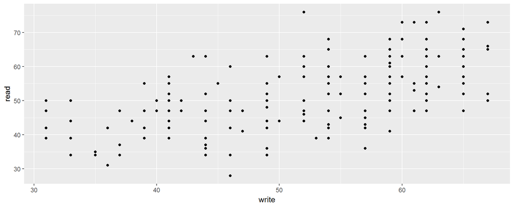

```r
# a scatterplot of read vs write
ggplot(data=d, aes(x=write, y=read)) + geom_point()
```

## Exploring continuous Variables: Histograms

We can inspect the distributions of continuous variables with histograms, density plots, and boxplots. Each of these plots has a corresponding `ggplot2` geom.

Histograms bin continuous variables into intervals and count the frequency of observations in each interval.

For histograms and density plots, we will map the variable of interest to `x`.

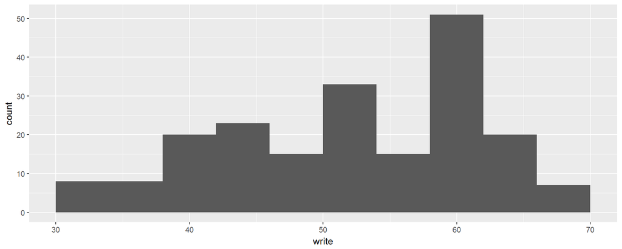

```r
# use the bins= argument to control the number of intervals
ggplot(d, aes(x=write)) + geom_histogram(bins=10)
```

We can also look at distributions for a subset of our data. Here we examine the distribution for write for students with math score below the mean math score:

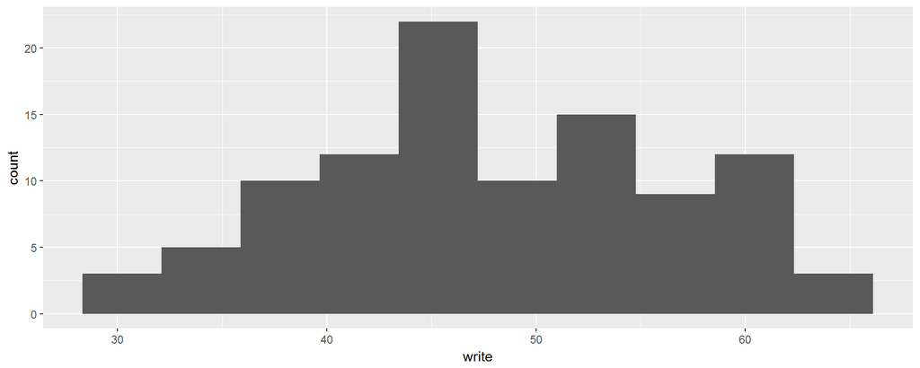

```r
# Requesting the rows where math is less than its mean
ggplot(d[d$math < mean(d$math),],
       aes(x=write)) + geom_histogram(bins=10)
```

## Exploring continuous vars: Density plots

Density Plots smooth out the shape of histograms:

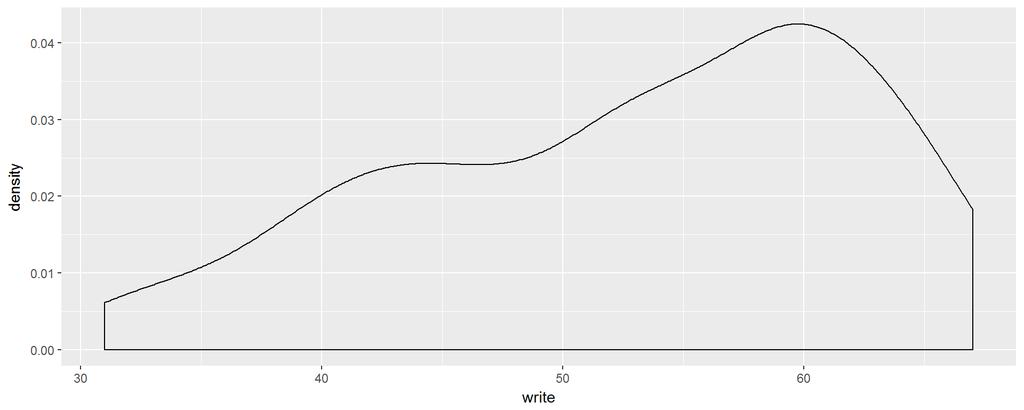

```r
ggplot(d, aes(x = write)) + geom_density()
```

## Exploring continuous vars: boxplots

Boxplots show the median, lower and upper quartiles (the hinges), and outliers.Unlike histograms and density plots, map the variable whose distribution we want to plot to y instead of x. If we are making a single boxplot, we need an arbitrary value for x, just as a place holder.

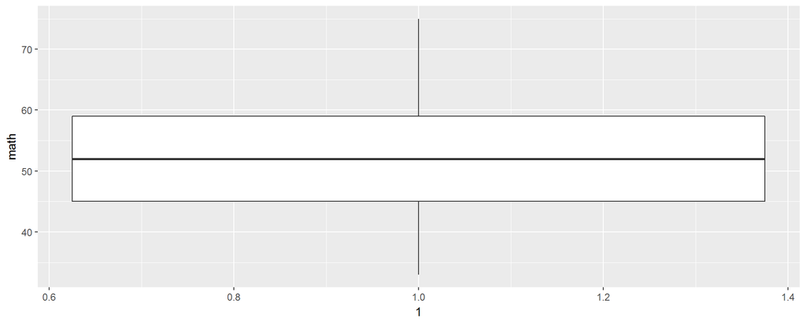

```r
# for the overall distribution of one variable, specify x=1 (or any other value)
ggplot(d, aes(x = 1, y = math)) + geom_boxplot()
```

Data exploration can help us identify suspicious looking values. This value of -99 on science is probably a code for a missing value.

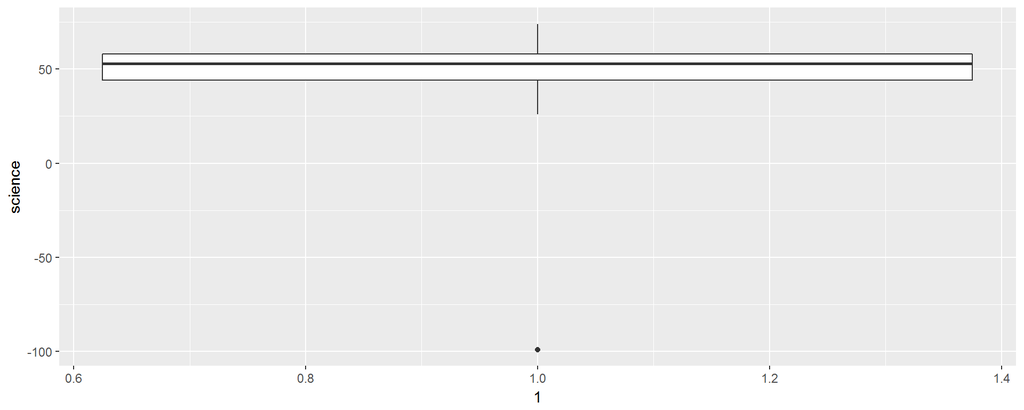

```r
# for the overall distribution of one variable, specify x=1 (or any other value)
ggplot(d, aes(x = 1, y = science)) + geom_boxplot()
```

## Exploring categorical variables

The statistics mean, median and variance cannot be calculated meaningfully for categorical variables (unless just 2 categories).

Instead, we often present frequency tables of the distribution of membership to each category.

Use `table()` to produce frequency tables.

Use `prop.table()` on the tables produced by `table()` (i.e. the output) to see the frequencies expressed as proportions.

Some of the categorical variables in this dataset are:

prog: educational program, "general", "academic", and "vocation" female: gender, "male" and "female" honors: enrollment in honors program, "enrolled" and "not enrolled" ses: socioeconomic status, "low", "middle", "high"

```r
# table() produces counts
table(d$female)
```

```
#>
#> female   male
#>    109     91
```

```r
table(d$ses)
```

```
#>
#>   high    low middle
#>     58     47     95
```

```r
# for proportions, use output of table()
#   as input to prop.table()
prop.table(table(d$female))
```

```
#>
#> female   male
#>  0.545  0.455
```

```r
prop.table(table(d$ses))
```

```
#>
#>   high    low middle
#>  0.290  0.235  0.475
```

## Factors

As you may have noticed in the previous section, `table()` orders the categories of prog and ses alphabetically. Unfortunately, the ordering high-low-middle is not ideal for ses.

Factors in R provide a way to represent categorical variables both numerically and categorically. Basically, factors assign an integer number (beginning with 1) to each distinct category, and then a character label to each category.

We convert character variables to factors with `factor()`. Specify the names of the categories in the levels= argument, in an order that makes sense to you. If you omit `levels=`, R will alphabetically sort the categories.

Use `levels()` on a factor to check the ordering of levels.

Note: The Base R function `read.csv()` by default reads in character variables as factors using alphabetical ordering, which is not always desirable. Thus we recommend the `readr` (part of `tidyverse`) function `read_csv()`, which leaves them as character.

```r
# before, ses is a character variable
str(d$ses)
```

```
#>  chr [1:200] "low" "middle" "high" "low" "middle" "high" "middle" ...
```

```r
# converting ses to factor
#   we need to specify levels explicitly, otherwise R will
#   sort alphabetically
d$ses <- factor(d$ses, levels=c("low", "middle", "high"))

# Now a factor, notice the integer representation
str(d$ses)
```

```
#>  Factor w/ 3 levels "low","middle",..: 1 2 3 1 2 3 2 2 2 2 ...
```

```r
# levels() reveals all factors in order
levels(d$ses)
```

```
#> [1] "low"    "middle" "high"
```

## Factors are represented both by their integers and their character labels.

Factors are converted to 0/1 variables in regression models.

```r
head(d$ses)
```

```
#> [1] low    middle high   low    middle high
#> Levels: low middle high
```

```r
head(as.numeric(d$ses))
```

```
#> [1] 1 2 3 1 2 3
```

```r
# the first observation of ses is equal to "low"...
d$ses[1] == "low"
```

```
#> [1] TRUE
```

```r
# ...and its underlying integer is equal to 1
as.numeric(d$ses[1]) == 1
```

```
#> [1] TRUE
```

Let's go ahead and convert some of the other character variables into factors:

```r
# alphabetic ordering fine here, so no need to specify levels
d$female <- factor(d$female)
levels(d$female)
```

```
#> [1] "female" "male"
```

```r
d$prog <- factor(d$prog)
levels(d$prog)
```

```
#> [1] "academic" "general"  "vocation"
```

## Exploring categorical vars: Bar graphs

Distributions of categorical variables are often depicted by bar graphs, which are easily made in ggplot2. By default, geom_bar() counts the number of observations for each value of the variable mapped to x.

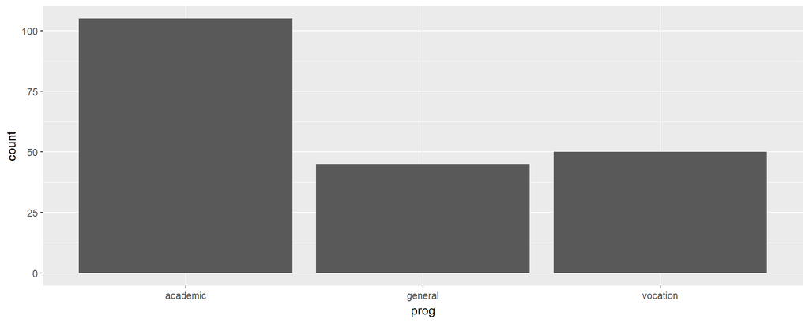

```r
ggplot(d, aes(x=prog)) + geom_bar()
```

## Exploring relationships between two variables

After inspecting distributions of variables individually, we then proceed to explore relationships between variables. Namely, we are generally interested whether the values of one variable are independent of the other, or whether they are associated (i.e. correlated or predictive).

We use different numerical and graphical methods for exploration depending on whether the two variables are both continuous, both categorical, or one of each.

## Exploring continuous by continuous numerically

Correlations provide quick assessments of whether two continuous variables are linearly related to one another.

The cor() function estimates correlations. If supplied with 2 vectors, cor() will estimate a single correlation. If supplied a data frame with several variables, cor() will estimate a correlation matrix.

```r
# just a single correlation
cor(d$write, d$read)
```

```
#> [1] 0.5967765
```

```r
# now isolate all test score variables
scores <- d[, c("read", "write", "math", "science", "socst")]
cor(scores)
```

```
#>              read     write      math   science     socst
#> read    1.0000000 0.5967765 0.6622801 0.1709428 0.1814928
#> write   0.5967765 1.0000000 0.6174493 0.1289845 0.1504587
#> math    0.6622801 0.6174493 1.0000000 0.2051668 0.1898648
#> science 0.1709428 0.1289845 0.2051668 1.0000000 0.9361672
#> socst   0.1814928 0.1504587 0.1898648 0.9361672 1.0000000
```

## Exploring continuous by continuous graphically

Scatter plots are an obvious choice to depict the relationship between 2 variables. We can also add a loess smooth layer (geom_smooth()) that provides a "best-fit" curve to the data.

Note that further layers are added with +.

Here we examine the relationship between reading test score and writing test score.

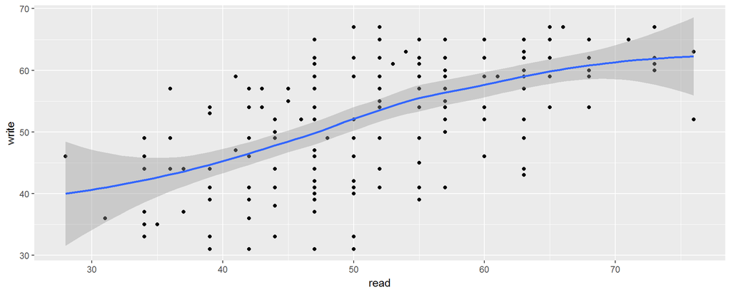

```r
# both scatter plot and loess smooth layers
ggplot(d, aes(x=read, y=write)) +
  geom_point() +
  geom_smooth()
```

## Exploring continuous by categorical: grouping data frames

When exploring the relationship between a continuous variable and categorical variable, we are often interested in whether the distribution (i.e. mean, variance, etc.) of the continuous variable is the same between the classes of the categorical variable.

For example, we might want to know whether the means and variances of math test scores are the same between males and females.

The `dplyr` package (part of ``tidyverse`) provides a useful function, `group_by()`, which converts a data frame into a grouped data frame, grouped by one or more variables. After grouping the data frame, we then use the dplyr function `summarize()` to calculate statistics by group.

```r
# first we group our data frame, d, by female
by_female <- group_by(d, female)

# notice that it is a grouped_df (data frame) now
class(by_female)
```

```
#> [1] "grouped_df" "tbl_df"     "tbl"        "data.frame"
```

Specify a function to evaluate a variable by groups in summarize(). First specify the (grouped) dataset, then the functions to run on variables in the dataset.

Here we get the means and variances of math by gender. We see that the means are nearly the same, but the variance seems higher in males.

```r
summarize(by_female, mean(math), var(math))
```

```
#> # A tibble: 2 x 3
#>   female `mean(math)` `var(math)`
#>   <fctr>        <dbl>       <dbl>
#> 1 female     52.39450    83.74108
#> 2   male     52.94505    93.40806
```

## Exploring continuous by categorical graphically

To plot the distributions of the continuous variables by groups defined by the categorical variables, we will plot separate density plots and boxplots of the continuous variables for each group of the categorical variable.

The distributions look very similar, with similar means, and a slightly more spread out shape for males.

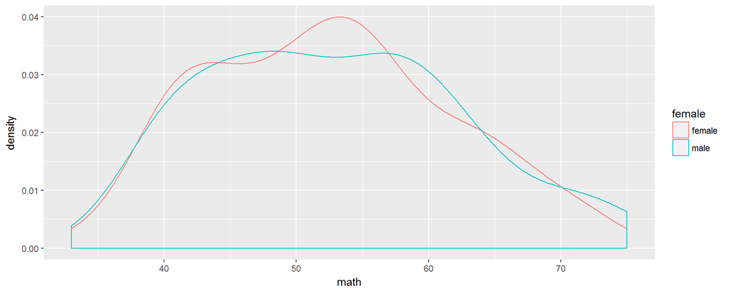

```r
ggplot(d, aes(x=math, color=female)) +
  geom_density()
```

Boxplots of math by female show the same similar looking distributions.

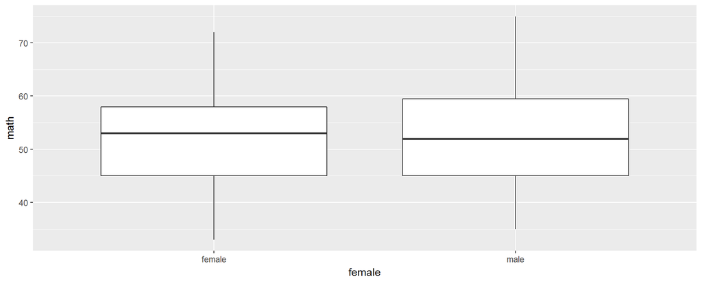

```r
ggplot(d, aes(x=female, y=math)) +
  geom_boxplot()
```

## Exploring categorical by categorical

Two-way and multi-way frequency tables are used to explore the relationships between categorical variables.

We can use `table()` and `prop.table()` again. Within `prob.table()`, use `margin=1` for row proportions and `margin=2` for column proportions. Omitting `margin=` will give proportions of the total.

Here, we check whether the proportions of observations that fall into each educational program (prog), are about the same across socioeconomic statuses.

```r
# this time saving the freq table to an object
my2way <- table(d$prog, d$ses)
# counts in each crossing of prog and ses
my2way
```

```
#>
#>            low middle high
#>   academic  19     44   42
#>   general   16     20    9
#>   vocation  12     31    7
```

Seems to be association between being in the academic program and in high ses.

```r
# row proportions,
#   proportion of prog that falls into ses
prop.table(my2way, margin=1)
```

```
#>
#>                  low    middle      high
#>   academic 0.1809524 0.4190476 0.4000000
#>   general  0.3555556 0.4444444 0.2000000
#>   vocation 0.2400000 0.6200000 0.1400000
```

```r
# columns proportions,
#   proportion of ses that falls into prog
prop.table(my2way, margin=2)
```

```
#>
#>                  low    middle      high
#>   academic 0.4042553 0.4631579 0.7241379
#>   general  0.3404255 0.2105263 0.1551724
#>   vocation 0.2553191 0.3263158 0.1206897
```

## Exploring categorical by categorical graphically

We can add a categorical variable to the bar graph of the other categorical variable to depict their relationship.

Here we map prog to `fill`, the color used to fill the bars of the bar graph. (The `color` aesthetic specifies the color of the outline of the bars)

This produces a stacked bar chart. We again see that "high" ses has a higher proportion of "academic"

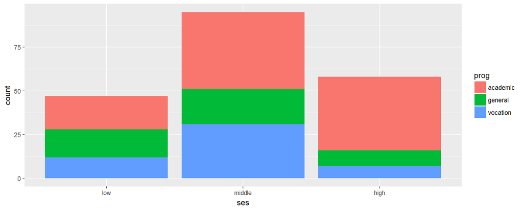

```r
ggplot(d, aes(x=ses, fill=prog)) +
  geom_bar()
```

The position argument in `geom_bar()` changes how the colors are sorted on the graph. We can specify that the color positions should `stack` (the default), `dodge` (side-by-side), or `fill` (uniform height to examine proportions).

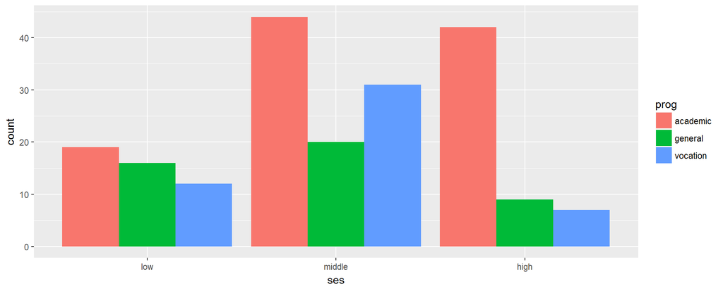

```r
ggplot(d, aes(x=ses, fill=prog)) +
  geom_bar(position="dodge")
```

## Adding more variables to graphs

One of the great strengths ggplot2 is how easy it is to map more variables to graphical aspects of the graph.

Graphs of 3 or more variables allow us to assess interactions of variables.

Adding color by prog to our scatter plot of read vs write. Now we can assess whether the read-write relationship appears the same between programs.

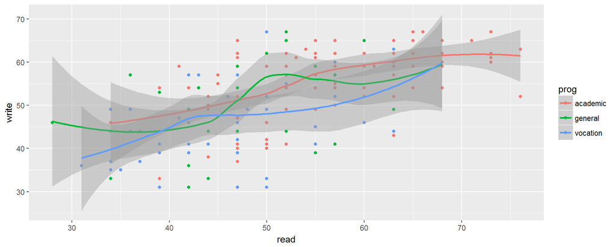

```r
# both scatter plot and loess smooth layers
ggplot(d, aes(x=read, y=write, color=prog)) +
  geom_point() +
  geom_smooth()
```

Faceting in ggplot2 is creating multiples (panels) of a plot by a grouping variable.

In the function facet_wrap(), specify a grouping variable by which to split the plots after the ~.

Below we split our plots of prog-by-ses by female.

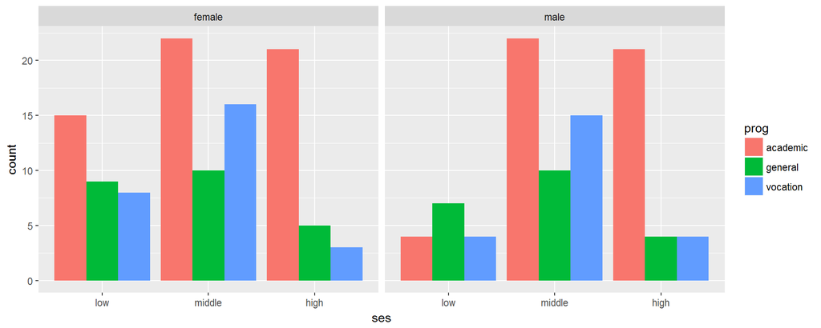

```r
# all functions after ggplot know
#   to look for variables in dataset "d"
ggplot(d, aes(x=ses, fill=prog)) +
  geom_bar(position="dodge") +
  facet_wrap(~female)
```

## Base R graphics

Base `R` graphics are easy to create, but not nearly as easy to customize and modernize as `ggplot2` graphs. We present some of the graphs created earlier, but now in base `R` graphics.

Base R histograms

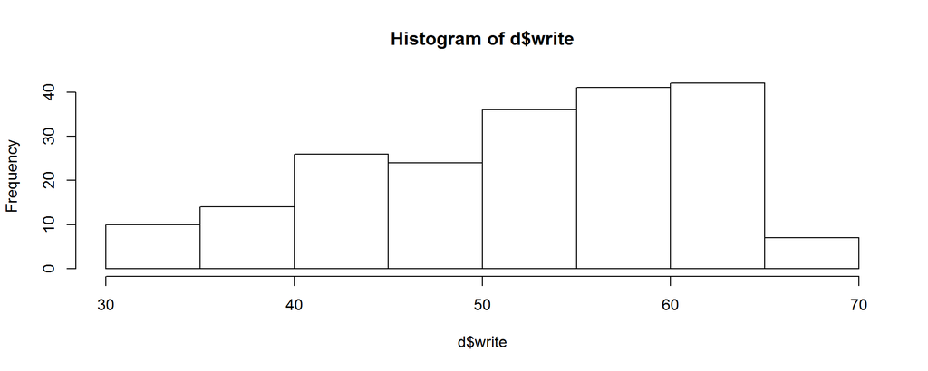

```r
hist(d$write)
```

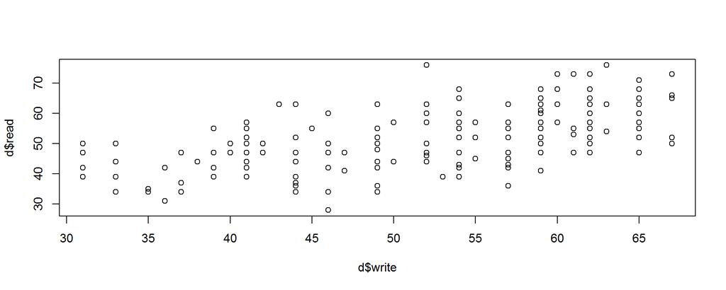

```r
plot(d$write, d$read)
```

Base R bar graph

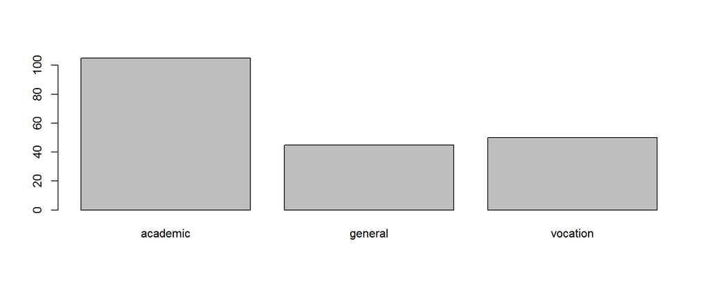

```r
# barplot wants a table input, not a data frame
#   (ggplot always wants a data.frame)
barplot(table(d$prog))
```

Coloring a scatter plot by groups

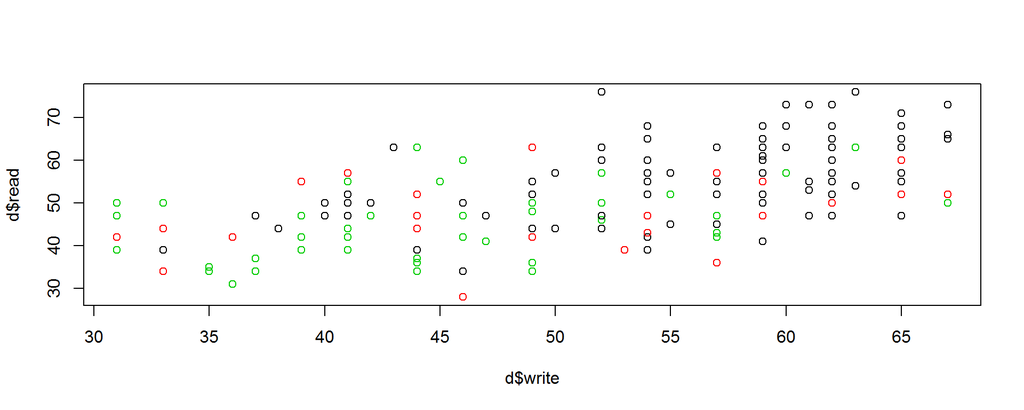

```r
plot(d$write, d$read, col=d$prog)
```

## Review: Data Exploration

What are a couple of things we can learn from this density plot of awards? Why does it look wrong?

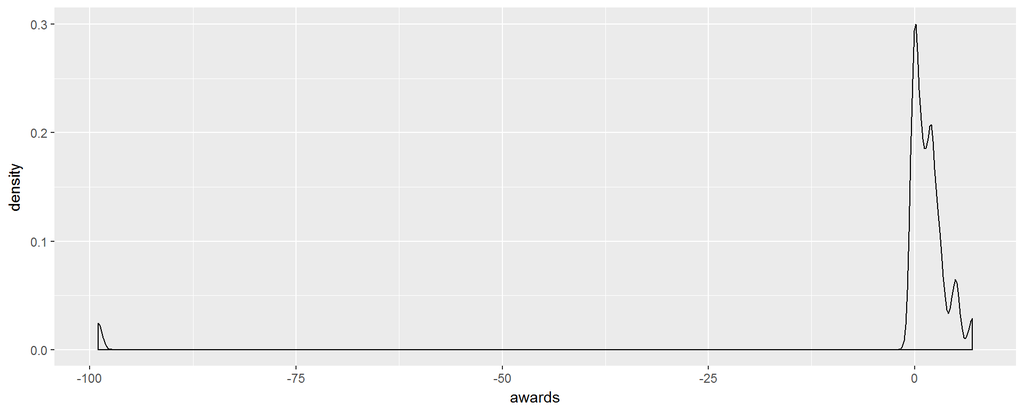

```r
ggplot(d, aes(x=awards)) + geom_density()
```

Awards has a pretty small range, with most values near 0, and very negative value is probably a missing data code.

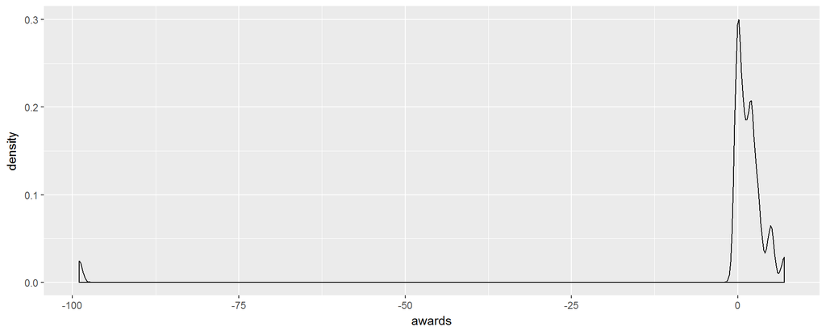

```r
ggplot(d, aes(x=awards)) + geom_density()
```

How would I obtain the maximum math score for each prog group? (hint: use group_by() and summarize())

```r
# these are the progs again
table(d_semi$prog)
```

```
#>
#> academic  general vocation
#>      105       45       50
```

First create a grouped data frame with group_by(), then use summarize() and function max() on math

```r
by_prog <- group_by(d_semi, prog)
summarize(by_prog, max(math))
```

```
#> # A tibble: 3 x 2
#>       prog `max(math)`
#>      <chr>       <dbl>
#> 1 academic          75
#> 2  general          63
#> 3 vocation          75
```

Here are the median and inter-quartile ranges (distance between first and third quartiles) of math scores by prog. Describe how the subsequent graph will appear.

```r
by_prog <- group_by(d_semi, prog)
summarize(by_prog, median(math), IQR(math))
```

```
#> # A tibble: 3 x 3
#>       prog `median(math)` `IQR(math)`
#>      <chr>          <dbl>       <dbl>
#> 1 academic             57       13.00
#> 2  general             49       14.00
#> 3 vocation             45       11.75
```

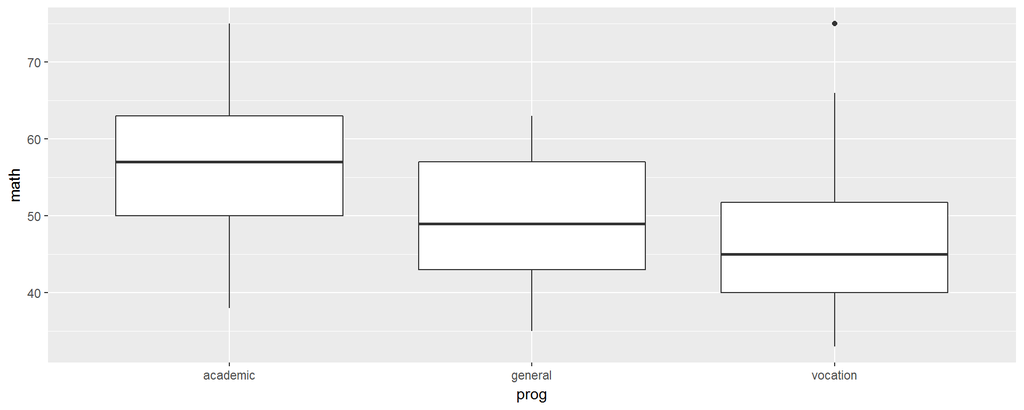

```r
ggplot(d, aes(x=prog, y=math)) + geom_boxplot()
```

## Data Management

Preparing our dataset for statistical analysis Now that we have familiarized ourselves with our dataset variables and their relationships, we should clean up any data entry errors and create additional variables or datasets that we might need for our planned statistical analysis.

Let's begin by reading in our dataset again and storing it in object d.

```r
# read data in
d <- read_csv("https://stats.idre.ucla.edu/stat/data/hsbraw.csv")
```

## Sorting

We can sort the order of rows in our data frame by variable values using the `arrange` function from the `dplyr` package (part of `tidyverse`).

Here we are requesting that `arrange` sort by `science`, and then by `socst`. The function `arrange` returns the sorted dataset.

Hmmm, we see those -99 values again…

```r
d <- arrange(d, science, socst)
d
```

```
#> # A tibble: 200 x 13
#>       id female    ses  schtyp     prog  read write  math science socst
#>    <int>  <chr>  <chr>   <chr>    <chr> <int> <int> <int>   <int> <int>
#>  1    53   male middle  public vocation    34    37    46     -99   -99
#>  2   191 female   high private academic    47    52    43     -99   -99
#>  3     9   male middle  public vocation    48    49    52     -99   -99
#>  4   159   male   high  public academic    55    61    54     -99   -99
#>  5    71 female middle  public  general    57    62    56     -99   -99
#>  6   144   male   high  public  general    60    65    58     -99   -99
#>  7    61 female   high  public academic    76    63    60     -99   -99
#>  8    15   male   high  public vocation    39    39    44      26    42
#>  9    45 female    low  public vocation    34    35    41      29    26
#> 10    51 female   high  public  general    42    36    42      31    39
#> # ... with 190 more rows, and 3 more variables: honors <chr>,
#> #   awards <int>, cid <int>
```

## Missing values

Missing values in R are represented by the reserved symbol NA (cannot be used for variable names).

Blank fields in a text file will generally be converted to NA.

We can convert the -99 values in science to NA with conditional selection.

```r
# subset to science values equal to -99, and then change
d$science[d$science == -99] <- NA
head(d$science, 10)
```

```
#>  [1] NA NA NA NA NA NA NA 26 29 31
```

That works, but what if we suspect there might be -99 values in other variables? If we know beforehand what our missing value codes are, we can specify them in read_csv() with the na= argument and save ourselves the work of conversion.

In the code below, we are specifying that the following should be interpreted as missing for `read_csv()`:

- "" (blank field)
- -99
- "-99" for character variables
- "NA"

We can see some NA values in science and socst.

```r
# read in data, specifying missing data codes
d <- read_csv("https://stats.idre.ucla.edu/stat/data/hsbraw.csv",
              na=c("", -99, "-99", "NA"))
d
```

```
#> # A tibble: 200 x 13
#>       id female    ses schtyp     prog  read write  math science socst
#>    <int>  <chr>  <chr>  <chr>    <chr> <int> <int> <int>   <int> <int>
#>  1    45 female    low public vocation    34    35    41      29    26
#>  2   108   male middle public  general    34    33    41      36    36
#>  3    15   male   high public vocation    39    39    44      26    42
#>  4    67   male    low public vocation    37    37    42      33    32
#>  5   153   male middle public vocation    39    31    40      39    51
#>  6    51 female   high public  general    42    36    42      31    39
#>  7   164   male middle public vocation    31    36    46      39    46
#>  8   133   male middle public vocation    50    31    40      34    31
#>  9     2 female middle public vocation    39    41    33      42    41
#> 10    53   male middle public vocation    34    37    46      NA    NA
#> # ... with 190 more rows, and 3 more variables: honors <chr>,
#> #   awards <int>, cid <int>
```

You cannot check for equality to NA, as it means "undefined". It will always result in NA.

Use `is.na()` instead.

```r
x <- c(1, 2, NA)
x == NA
```

```
#> [1] NA NA NA
```

```r
is.na(x)
```

```
#> [1] FALSE FALSE  TRUE
```

Missing values are contagious Most operations involving and NA value will result in NA:

```r
1 + 2 + NA
```

```
#> [1] NA
```

```r
c(1, 2, 3, NA) > 2
```

```
#> [1] FALSE FALSE  TRUE    NA
```

```r
mean(c(1,2,3,4,NA))
```

```
#> [1] NA
```

However, many functions allow the argument na.rm (or soemthing similar) to be set to TRUE, which will first remove any NA values from the operation before calculating the result:

```r
# NA values will be removed first
sum(c(1,2,NA), na.rm=TRUE)
```

```
#> [1] 3
```

```r
mean(c(1,2,3,4,NA), na.rm=TRUE)
```

```
#> [1] 2.5
```

## String functions

Base `R` comes with several functions useful for manipulating string (character) variables.

String variables are notoriously messy, often with typos and extra spaces. One of the advantages of `dplyr read_csv()` over base `R` `read.csv()` is that `read_csv()` will remove leading and trailing spaces by default, while `read.csv()` will not.

Two common tasks with strings are extracting substrings and concatenating strings together

Use `substr()` to extract a part of a character variable, specified by the `start=` position and the `stop=` position.

Imagine we needed to abbreviate our prog names, so that they fit well in a graph or table. We can create a variable consisting of the first 3 letters of prog like so:

```r
# extract starting at first character, stopping at third
d$prog_short <- substr(d$prog, start=1, stop=3)

head(d[,c("prog", "prog_short")], n=5)
```

```
#> # A tibble: 5 x 2
#>       prog prog_short
#>      <chr>      <chr>
#> 1 vocation        voc
#> 2  general        gen
#> 3 vocation        voc
#> 4 vocation        voc
#> 5 vocation        voc
```

For concatenating strings together, use `paste()`. The `sep=` argument specifies which character delimits the strings (space by default).

Below we combine the schtyp (school type) and ses variables into a single variable by pasting their contents together.

```r
d$schtyp_ses1 <- paste(d$schtyp, d$ses, sep=" ")
head(d[, c("schtyp", "ses", "schtyp_ses1")], n=5)
```

```
#> # A tibble: 5 x 3
#>   schtyp    ses   schtyp_ses1
#>    <chr>  <chr>         <chr>
#> 1 public    low    public low
#> 2 public middle public middle
#> 3 public   high   public high
#> 4 public    low    public low
#> 5 public middle public middle
```

```r
# changing the delimiter to comma
d$schtyp_ses2 <- paste(d$schtyp, d$ses, sep=",")
head(d[, c("schtyp", "ses", "schtyp_ses2")], n=5)
```

```
#> # A tibble: 5 x 3
#>   schtyp    ses   schtyp_ses2
#>    <chr>  <chr>         <chr>
#> 1 public    low    public,low
#> 2 public middle public,middle
#> 3 public   high   public,high
#> 4 public    low    public,low
#> 5 public middle public,middle
```

`grep()` for partial string matching If you need find matches of a given pattern within strings of a vector (does not have to be a whole word match), use `grep()`.

By default `grep()` returns the index number of the matches. Use the argument specification `value=TRUE` to return the actual strings themselves.

```r
my_char_vec <- c("here", "are", "some", "words", "to", "explore")
grep(pattern="re", x=my_char_vec)
```

```
#> [1] 1 2 6
```

```r
grep("re", my_char_vec, value=TRUE)
```

```
#> [1] "here"    "are"     "explore"
```

## Transforming variables

Often we need to create variables from other variables. For example, we may want to sum individual test items to form a total score. Or, we may want to convert a continuous scale into several categories, such as letter grades.

Here are some useful functions to transform variables:

- `log()`: logarithm
- `min_rank()`: rank values
- `cut()`: cut a continuous variable into intervals, and new value signifies into which interval the original value valls.
- `scale()`: standardizes variable (substracts mean and divides by standard deviation)
- `lag()`, `lead()`: lag and lead a variable
- `cumsum()`: cumulative sum
- `rowMeans()`, `rowSums()`: means and sums of several columns

## Adding new variables to the data frame

You can add variables to data frames by declaring them to be column variables of the data frame as they are created.

Trying to add a column of the wrong length will result in an error.

```r
# this will add a column variable called logwrite to d
d$logwrite <- log(d$write)

# now we see logwrite as a column in d
colnames(d)
```

```
#>  [1] "id"          "female"      "ses"         "schtyp"      "prog"
#>  [6] "read"        "write"       "math"        "science"     "socst"
#> [11] "honors"      "awards"      "cid"         "prog_short"  "schtyp_ses1"
#> [16] "schtyp_ses2" "logwrite"
```

```r
#d has 200 rows, and the rep vector has 300
# d$z <- rep(0, 300)
```

## Tranforming many variables at once with `mutate()`

The dplyr function `mutate()` allows us to transform many variables in one step without having to respecify the data frame name over and over.

Below we transform math in 4 different ways.

```r
# create 4 transformations of math
d <- mutate(d,
            logmath = log(math),
            mathrank = min_rank(math),
            mathgrade = cut(math,
                            breaks = c(0, 35, 45, 55, 65, 80),
                            labels = c("F", "D", "C", "B", "A")),
            zmath = scale(math)
            )
```

Subsetting rows of a data frame with filter() We have already seen how to subset using logical vectors and logical subsetting:

```r
# subset to observations with max reading score
max_read <- d[d$read==max(d$read),]
max_read
```

```
#> # A tibble: 2 x 21
#>      id female   ses schtyp     prog  read write  math science socst
#>   <int>  <chr> <chr>  <chr>    <chr> <int> <int> <int>   <int> <int>
#> 1   103   male  high public academic    76    52    64      64    61
#> 2    61 female  high public academic    76    63    60      NA    NA
#> # ... with 11 more variables: honors <chr>, awards <int>, cid <int>,
#> #   prog_short <chr>, schtyp_ses1 <chr>, schtyp_ses2 <chr>,
#> #   logwrite <dbl>, logmath <dbl>, mathrank <int>, mathgrade <fctr>,
#> #   zmath <dbl>
```

While that works fine enough, the code can get unwieldy if there are many conditions that need to be evaluated.

The dplyr function `filter()` provides a cleaner syntax for subsetting datasets.

```r
# subset to females with high math
d_fem_hi_math <- filter(d, female == "female" & math > 50)
head(d_fem_hi_math, n=3)
```

```
#> # A tibble: 3 x 21
#>      id female    ses schtyp     prog  read write  math science socst
#>   <int>  <chr>  <chr>  <chr>    <chr> <int> <int> <int>   <int> <int>
#> 1     8 female    low public academic    39    44    52      44    48
#> 2   142 female middle public vocation    47    42    52      39    51
#> 3   151 female middle public vocation    47    46    52      48    46
#> # ... with 11 more variables: honors <chr>, awards <int>, cid <int>,
#> #   prog_short <chr>, schtyp_ses1 <chr>, schtyp_ses2 <chr>,
#> #   logwrite <dbl>, logmath <dbl>, mathrank <int>, mathgrade <fctr>,
#> #   zmath <dbl>
```

```r
# subset to students with math < 50 in the general or academic programs
d_gen_aca_low_math <- filter(d, (prog == "general" | prog == "academic") & math < 50)
head(d_gen_aca_low_math, n=3)
```

```
#> # A tibble: 3 x 21
#>      id female    ses schtyp     prog  read write  math science socst
#>   <int>  <chr>  <chr>  <chr>    <chr> <int> <int> <int>   <int> <int>
#> 1   108   male middle public  general    34    33    41      36    36
#> 2    51 female   high public  general    42    36    42      31    39
#> 3   128   male   high public academic    39    33    38      47    41
#> # ... with 11 more variables: honors <chr>, awards <int>, cid <int>,
#> #   prog_short <chr>, schtyp_ses1 <chr>, schtyp_ses2 <chr>,
#> #   logwrite <dbl>, logmath <dbl>, mathrank <int>, mathgrade <fctr>,
#> #   zmath <dbl>
```

## Adding Observations (appending by rows)

Sometimes we are given our dataset in parts, with observations spread over many files (collected by different researchers, for example). To create one dataset, we need to append the datasets together row-wise.

The function `rbind()` appends data frames together. The variables must be the same between datasets.

Here, we `rbind()` the two datasets we created with `filter()` above, and check that it was successful by calculating the number of rows.

```r
# rbind works because they have the same variables
d_append <- rbind(d_fem_hi_math, d_gen_aca_low_math)

# dimensions of component datasets
dim(d_fem_hi_math)
```

```
#> [1] 62 21
```

```r
dim(d_gen_aca_low_math)
```

```
#> [1] 47 21
```

```r
# appended dataset has rows = sum of rows of components
dim(d_append)
```

```
#> [1] 109  21
```

## Subsetting Variables (columns)

Often, datasets come with many more variable than we want. We can use the dplyr function select() to keep only the variables we need.

```r
# select 4 variables
d_use <- select(d, id, female, read, write)
head(d_use, n=3)
```

```
#> # A tibble: 3 x 4
#>      id female  read write
#>   <int>  <chr> <int> <int>
#> 1    45 female    34    35
#> 2   108   male    34    33
#> 3    15   male    39    39
```

```r
# select everything BUT female, read, write
# note the - preceding c(female...)
d_dropped <- select(d, -c(female, read, write))
head(d_dropped, n=3)
```

```
#> # A tibble: 3 x 18
#>      id    ses schtyp     prog  math science socst       honors awards
#>   <int>  <chr>  <chr>    <chr> <int>   <int> <int>        <chr>  <int>
#> 1    45    low public vocation    41      29    26 not enrolled      0
#> 2   108 middle public  general    41      36    36 not enrolled      0
#> 3    15   high public vocation    44      26    42 not enrolled      0
#> # ... with 9 more variables: cid <int>, prog_short <chr>,
#> #   schtyp_ses1 <chr>, schtyp_ses2 <chr>, logwrite <dbl>, logmath <dbl>,
#> #   mathrank <int>, mathgrade <fctr>, zmath <dbl>
```

## Adding columns of data

If we know that the rows of data of 2 columns (or two data frames) correspond to the same observations, we can use cbind() to combine the columns into a single data frame. Columns combined this way must have the same number of rows.

The rows of the two data frames we just created with `select()` indeed do correspond to the same observations:

```r
d_all <- cbind(d_use, d_dropped)
head(d_all, n=3)
```

```
#>    id female read write  id    ses schtyp     prog math science socst
#> 1  45 female   34    35  45    low public vocation   41      29    26
#> 2 108   male   34    33 108 middle public  general   41      36    36
#> 3  15   male   39    39  15   high public vocation   44      26    42
#>         honors awards cid prog_short   schtyp_ses1   schtyp_ses2 logwrite
#> 1 not enrolled      0   1        voc    public low    public,low 3.555348
#> 2 not enrolled      0   1        gen public middle public,middle 3.496508
#> 3 not enrolled      0   1        voc   public high   public,high 3.663562
#>    logmath mathrank mathgrade      zmath
#> 1 3.713572       22         D -1.2430021
#> 2 3.713572       22         D -1.2430021
#> 3 3.784190       43         D -0.9227783
```

## Adding data columns by merging on a key variable

More often, we receive separate datasets with different variables (columns) that must be merged on a key variable.

Merging is an involved topic, with many different kinds of merges possible, depending on whether every observation in one dataset can be matched to an observation in the other dataset. Sometimes, you'll want to keep observations in one dataset, even if it is not matched. Other times, you will not.

We will solely demonstrate merges where only matched observations are kept.

Earlier in the seminar, we learned how to use the `dplyr` functions `group_by()` and `summarize()` to get statistics by group.

Let's use those tools again to get statistics by class (dataset variable cid), namely the class means and medians on math. This time, we will store the output dataset in an object.

```r
# first group data by cid (there are 20 classes)
by_class <- group_by(d, cid)
# then get mean/median on math by class
class_stats <- summarize(by_class, meanmath=mean(math), medmath=median(math))
class_stats
```

```
#> # A tibble: 20 x 3
#>      cid meanmath medmath
#>    <int>    <dbl>   <dbl>
#>  1     1 41.36364    41.0
#>  2     2 40.50000    39.5
#>  3     3 43.77778    44.0
#>  4     4 44.72727    43.0
#>  5     5 44.45455    44.0
#>  6     6 47.11111    46.0
#>  7     7 48.11111    49.0
#>  8     8 49.81818    50.0
#>  9     9 50.77778    51.0
#> 10    10 50.80000    51.5
#> 11    11 49.91667    50.5
#> 12    12 55.40000    54.0
#> 13    13 54.44444    53.0
#> 14    14 58.00000    57.5
#> 15    15 58.70000    59.0
#> 16    16 57.18182    57.0
#> 17    17 61.14286    62.0
#> 18    18 63.30000    63.0
#> 19    19 66.00000    66.0
#> 20    20 69.80000    71.0
```

Conveniently, the class_stats dataset includes cid, which we will use as our key variable for merging.

Here, we will use the `dplyr()` function `inner_join()` to merge the datasets (base`R` function `merge()` is quite similar). `inner_join()` will search both datasets for any variables with the same name, and will use those as matching variables. If you need to control which variables are used to match, use the `by=` argument.

In our two datasets, the only variable that appears in both is cid, which we want to use as the key variable, so we do not need `by=:`

```r
d_merged <- inner_join(d, class_stats)
## Joining, by = "cid"

# showing just a few variable for space
head(select(d_merged, cid, math, meanmath, medmath))
```

```
#> # A tibble: 6 x 4
#>     cid  math meanmath medmath
#>   <int> <int>    <dbl>   <dbl>
#> 1     1    41 41.36364      41
#> 2     1    41 41.36364      41
#> 3     1    44 41.36364      41
#> 4     1    42 41.36364      41
#> 5     1    40 41.36364      41
#> 6     1    42 41.36364      41
```

## Review: Data Management

If TRUE = 1 and FALSE = 0, what is the result of sum(b<3)?

```r
b <- c(1,2,3,NA)
sum(b<3)
```

It's NA! Summing with NA results in NA. Remember to use na.rm=TRUE if you want to remove NA first.

```r
b <- c(1,2,3,NA)
sum(b<3)
```

```
#> [1] NA
```

```r
# remove NA first
sum(b<3, na.rm=TRUE)
```

```
#> [1] 2
```

Here is a dataset of names and phone numbers. How do I create a variable that is just the area code (without parenetheses)

```r
# tibble() is basically same as data.frame()
#  but adds class "tbl_df" to data.frame
directory <-
  tibble(names=c("Leo Smith", "Karen Smith",
                  "Audrey Jones", "Dylan Jones"),
         phone=c("(323)555-5432", "(323)555-5421",
                 "(213)555-2154", "(213)555-2155"))
```

Use substr() to extract from the second to fourth character from phone?

```r
directory <-
  data.frame(names=c("Leo Smith", "Karen Smith",
                     "Audrey Jones", "Dylan Jones"),
             phone=c("(323)555-5432", "(323)555-5421",
                     "(213)555-2154", "(213)555-2155"))

directory$area_code <- substr(directory$phone, 2, 4)

directory
```

```
#>          names         phone area_code
#> 1    Leo Smith (323)555-5432       323
#> 2  Karen Smith (323)555-5421       323
#> 3 Audrey Jones (213)555-2154       213
#> 4  Dylan Jones (213)555-2155       213
```

Imagine directory was much larger and had thousands or millions of rows? How could I subset the data to everyone with the name "Jones"?

```r
directory <-
  tibble(names=c("Leo Smith", "Karen Smith",
                  "Audrey Jones", "Dylan Jones"),
         phone=c("(323)555-5432", "(323)555-5421",
                 "(213)555-2154", "(213)555-2155"))
```

Use `grep()` for partial matches. Remember that grep() returns the indices of matches, so we can use the results of grep to subset our directory:

```r
directory <-
  tibble(names=c("Leo Smith", "Karen Smith",
                  "Audrey Jones", "Dylan Jones"),
         phone=c("(323)555-5432", "(323)555-5421",
                 "(213)555-2154", "(213)555-2155"))

# match "Jones" in names
my_jones <- grep("Jones", directory$names)
my_jones
```

```
#> [1] 3 4
```

```r
directory[my_jones,]
```

```
#> # A tibble: 2 x 2
#>          names         phone
#>          <chr>         <chr>
#> 1 Audrey Jones (213)555-2154
#> 2  Dylan Jones (213)555-2155
```

hese tibble data frames seem to have the same variables. Why doesn't rbind(y1, y2) work?

```r
y1 <- tibble(Names=c("Mary", "Sue"),
            scores=c(36, 78))
y2 <- tibble(names=c("John", "Jack"),
             scores=c(25, 44))
# what happened?
# rbind(y1, y2)
## Error in match.names(clabs, names(xi)): names do not match previous names
```

Case matters in R. "Names" and "names" are considered different. Make them the same to get rbind() to work:

```r
y1 <- tibble(names=c("Mary", "Sue"),
            scores=c(36, 78))
y2 <- tibble(names=c("John", "Jack"),
             scores=c(25, 44))

# what happened?
rbind(y1, y2)
```

```
#> # A tibble: 4 x 2
#>   names scores
#>   <chr>  <dbl>
#> 1  Mary     36
#> 2   Sue     78
#> 3  John     25
#> 4  Jack     44
```

In the code below, we split the dataset into two - one that contains the numeric test variables (read, write, math, science, and socst) and another that contains all other variables. We then sort the test variables dataset by math.

Why is running `cbind()` to re-merge the datasets a bad idea? After all, there is no error message…

```r
# create a datset of just test scores
test <- select(d, read, write, math, science, socst)

nontest <- select(d, -c(read, write, math, science, socst))

# sort test scores by test
test <- arrange(test, math)
```

```r
# cbind runs without error
remerged <- cbind(test, nontest)

# but what's wrong here?
head(remerged, n=3)
```

```
#>   read write math science socst  id female    ses schtyp     prog
#> 1   39    41   33      42    41  45 female    low public vocation
#> 2   63    49   35      66    41 108   male middle public  general
#> 3   36    44   37      42    41  15   male   high public vocation
#>         honors awards cid prog_short   schtyp_ses1   schtyp_ses2 logwrite
#> 1 not enrolled      0   1        voc    public low    public,low 3.555348
#> 2 not enrolled      0   1        gen public middle public,middle 3.496508
#> 3 not enrolled      0   1        voc   public high   public,high 3.663562
#>    logmath mathrank mathgrade      zmath
#> 1 3.713572       22         D -1.2430021
#> 2 3.713572       22         D -1.2430021
#> 3 3.784190       43         D -0.9227783
```

The problem is that cbind() does not know you sorted one of the two datasets, so now the order of observations is different between the two. Thus cbind() matches the wrong observations from the 2 datasets together.

Let's see how the observation with id = 1 appears in the original dataset and the remerged dataset:

```r
# the values on the test scores don't match!
rbind(d[d$id==1,], remerged[remerged$id==1,])
```

```
#> # A tibble: 2 x 21
#>      id female   ses schtyp     prog  read write  math science socst
#> * <int>  <chr> <chr>  <chr>    <chr> <int> <int> <int>   <int> <int>
#> 1     1 female   low public vocation    34    44    40      39    41
#> 2     1 female   low public vocation    39    54    39      47    36
#> # ... with 11 more variables: honors <chr>, awards <int>, cid <int>,
#> #   prog_short <chr>, schtyp_ses1 <chr>, schtyp_ses2 <chr>,
#> #   logwrite <dbl>, logmath <dbl>, mathrank <int>, mathgrade <fctr>,
#> #   zmath <dbl>
```

Instead, it is safer to use a merge variable. When first splitting the datasets, we should make sure an id variable appears in both dataset.

```r
test <- select(d, id, read, write, math, science, socst)

nontest <- select(d, -c(read, write, math, science, socst))

# sort test scores by test
test <- arrange(test, math)

# cbind runs without error
remerged2 <- merge(test, nontest)
```

```r
# these should match now
rbind(remerged2[remerged2$id==1,], d[d$id==1,])
```

```
#>   id read write math science socst female ses schtyp     prog       honors
#> 1  1   34    44   40      39    41 female low public vocation not enrolled
#> 2  1   34    44   40      39    41 female low public vocation not enrolled
#>   awards cid prog_short schtyp_ses1 schtyp_ses2 logwrite  logmath mathrank
#> 1      0   1        voc  public low  public,low  3.78419 3.688879       12
#> 2      0   1        voc  public low  public,low  3.78419 3.688879       12
#>   mathgrade     zmath
#> 1         D -1.349743
#> 2         D -1.349743
```